# Neural Network

Kirankumari Gopalji sheshma

2023-05-08

- Reading the train and test data set of digits

```r
data.train<-read.csv("digits.csv")
head(data.train)
```

```
##   V1 V2 V3 V4 V5     V6     V7     V8     V9    V10    V11    V12    V13    V14
## 1  0 -1 -1 -1 -1 -1.000 -1.000 -1.000 -1.000 -1.000 -1.000 -1.000 -1.000 -1.000
## 2  1 -1 -1 -1 -1 -1.000 -1.000 -0.905  0.704 -0.520 -1.000 -1.000 -1.000 -1.000
## 3  6 -1 -1 -1 -1 -1.000 -1.000 -1.000 -0.950  0.479  0.840 -0.858 -1.000 -1.000
## 4  3 -1 -1 -1 -1 -0.162  0.682  0.492  0.492  0.492  0.304 -0.233 -0.983 -1.000
## 5  1 -1 -1 -1 -1 -1.000 -1.000  0.157  0.922 -0.286 -0.984 -1.000 -1.000 -1.000
## 6  4 -1 -1 -1 -1 -1.000 -1.000 -1.000 -1.000 -1.000 -1.000 -1.000 -1.000 -0.131
##     V15 V16 V17 V18 V19 V20 V21    V22    V23    V24    V25    V26    V27
## 1 -1.00  -1  -1  -1  -1  -1  -1 -1.000 -1.000 -1.000 -0.902 -0.640 -0.783
## 2 -1.00  -1  -1  -1  -1  -1  -1 -1.000 -1.000 -0.971  0.848  0.154 -1.000
## 3 -1.00  -1  -1  -1  -1  -1  -1 -1.000 -1.000 -0.870  0.388  1.000  0.994
## 4 -1.00  -1  -1  -1  -1  -1  -1 -0.928  0.286  0.999  1.000  1.000  1.000
## 5 -1.00  -1  -1  -1  -1  -1  -1 -1.000 -0.832  0.930  1.000  1.000  0.171
## 6 -0.07  -1  -1  -1  -1  -1  -1 -1.000 -1.000 -1.000 -1.000 -1.000 -1.000
##      V28    V29    V30    V31 V32 V33 V34 V35 V36    V37    V38    V39    V40
```

[output cut: 146 more lines]

```r
dim(data.train)
```

```
## [1] 800 257
```

```r
data.test<-read.csv("digits_test.csv")
head(data.test)
```

```
##   V1 V2 V3 V4 V5 V6 V7     V8     V9    V10    V11    V12    V13    V14    V15
## 1  5 -1 -1 -1 -1 -1 -1 -1.000 -0.942 -0.635  0.284  1.000  0.628  0.111 -0.535
## 2  1 -1 -1 -1 -1 -1 -1 -1.000  0.132  0.553 -0.575 -1.000 -1.000 -1.000 -1.000
## 3  6 -1 -1 -1 -1 -1 -1 -1.000 -0.689  0.540  0.797  0.265 -0.909 -1.000 -1.000
## 4  6 -1 -1 -1 -1 -1 -1 -1.000 -0.996  0.275 -0.165 -1.000 -1.000 -1.000 -1.000
## 5  1 -1 -1 -1 -1 -1 -1 -0.809  0.810  0.443 -1.000 -1.000 -1.000 -1.000 -1.000
## 6  1 -1 -1 -1 -1 -1 -1 -1.000  0.474 -0.289 -1.000 -1.000 -1.000 -1.000 -1.000
##   V16 V17 V18 V19 V20 V21 V22    V23    V24    V25   V26    V27    V28    V29
## 1  -1  -1  -1  -1  -1  -1  -1 -0.705  0.283  0.390 0.996  1.000  1.000  1.000
## 2  -1  -1  -1  -1  -1  -1  -1 -1.000 -0.880  0.946 1.000  0.267 -1.000 -1.000
## 3  -1  -1  -1  -1  -1  -1  -1 -1.000 -1.000  0.265 1.000  0.922  0.535 -0.412
## 4  -1  -1  -1  -1  -1  -1  -1 -1.000 -1.000 -0.444 0.835 -0.667 -1.000 -1.000
## 5  -1  -1  -1  -1  -1  -1  -1 -1.000 -0.670  1.000 0.951 -0.650 -1.000 -1.000
## 6  -1  -1  -1  -1  -1  -1  -1 -1.000 -1.000  0.756 0.575 -1.000 -1.000 -1.000
##   V30 V31    V32 V33 V34 V35   V36    V37    V38    V39    V40   V41   V42
```

[output cut: 132 more lines]

```r
dim(data.test)
```

```
## [1] 200 257
```

```r
library(neuralnet)
library(nnet)
```

The scaling of the inputs can have a large effect on the quality of the final solution. It is best to standardize all inputs to have mean zero and standard deviation one. This ensures all inputs are treated equally in the regularization process.

```r
## Scale variables before doing neural network
zip.train_s <- data.train
zip.test_s <- data.test
scaled1 <- as.matrix(scale(data.train[,-1]))
zip.train_s[,-1] <- as.matrix(scaled1)
colnames(zip.train_s) <- paste("v", 1:ncol(zip.train_s), sep="")
scaled2 <- scale(data.test[,-1], center=attr(scaled1,"scaled:center"),
 scale=attr(scaled1,"scaled:scale"))
zip.test_s[,-1] <- as.matrix(scaled2)
colnames(zip.test_s) <- paste("v", 1:ncol(zip.test_s), sep="")
```

Pixels are the input nodes, and the 1st column (digit id (0-9)) is the output node. Because digit id is a factor (values: 0-9), we need to transfer it as dummy variables.

```r
# Create output nodes
a <- class.ind(zip.train_s[,1])
colnames(a) <- paste("a", colnames(a), sep="")
```

Use function neuralnet in package neuralnet to fit the neural network model. Notice that the argument hidden accepts a vector with the number of nodes (neurons) for each hidden layer. For example, 1 hidden layer with 2 nodes: hidden=c(2) ; 2 hidden layers with 1 and 2 nodes, respectively: hidden=c(1, 2) . We will be fitting 4 different neural network structures (Net-1 to Net-4):

```r
# Create model formula with all variables as predictors
yname<-colnames(a)
xname<-colnames(zip.train_s)[-1]
(fmla <- as.formula(paste(paste(yname, collapse="+"), " ~ ", paste(xname, collapse="+"))))
```

```
## a0 + a1 + a2 + a3 + a4 + a5 + a6 + a7 + a8 + a9 ~ v2 + v3 + v4 +
##     v5 + v6 + v7 + v8 + v9 + v10 + v11 + v12 + v13 + v14 + v15 +
##     v16 + v17 + v18 + v19 + v20 + v21 + v22 + v23 + v24 + v25 +
##     v26 + v27 + v28 + v29 + v30 + v31 + v32 + v33 + v34 + v35 +
##     v36 + v37 + v38 + v39 + v40 + v41 + v42 + v43 + v44 + v45 +
##     v46 + v47 + v48 + v49 + v50 + v51 + v52 + v53 + v54 + v55 +
##     v56 + v57 + v58 + v59 + v60 + v61 + v62 + v63 + v64 + v65 +
##     v66 + v67 + v68 + v69 + v70 + v71 + v72 + v73 + v74 + v75 +
##     v76 + v77 + v78 + v79 + v80 + v81 + v82 + v83 + v84 + v85 +
##     v86 + v87 + v88 + v89 + v90 + v91 + v92 + v93 + v94 + v95 +
##     v96 + v97 + v98 + v99 + v100 + v101 + v102 + v103 + v104 +
##     v105 + v106 + v107 + v108 + v109 + v110 + v111 + v112 + v113 +
##     v114 + v115 + v116 + v117 + v118 + v119 + v120 + v121 + v122 +
##     v123 + v124 + v125 + v126 + v127 + v128 + v129 + v130 + v131 +
##     v132 + v133 + v134 + v135 + v136 + v137 + v138 + v139 + v140 +
##     v141 + v142 + v143 + v144 + v145 + v146 + v147 + v148 + v149 +
##     v150 + v151 + v152 + v153 + v154 + v155 + v156 + v157 + v158 +
##     v159 + v160 + v161 + v162 + v163 + v164 + v165 + v166 + v167 +
##     v168 + v169 + v170 + v171 + v172 + v173 + v174 + v175 + v176 +
##     v177 + v178 + v179 + v180 + v181 + v182 + v183 + v184 + v185 +
##     v186 + v187 + v188 + v189 + v190 + v191 + v192 + v193 + v194 +
##     v195 + v196 + v197 + v198 + v199 + v200 + v201 + v202 + v203 +
##     v204 + v205 + v206 + v207 + v208 + v209 + v210 + v211 + v212 +
##     v213 + v214 + v215 + v216 + v217 + v218 + v219 + v220 + v221 +
##     v222 + v223 + v224 + v225 + v226 + v227 + v228 + v229 + v230 +
##     v231 + v232 + v233 + v234 + v235 + v236 + v237 + v238 + v239 +
##     v240 + v241 + v242 + v243 + v244 + v245 + v246 + v247 + v248 +
##     v249 + v250 + v251 + v252 + v253 + v254 + v255 + v256 + v257
```

```r
# Net-1: One hidden layer with 12 nodes
fitnn1 <- neuralnet(fmla, data=cbind(a, zip.train_s[,-1]),
 hidden=c(12),
 err.fct="ce", act.fct="logistic",
 linear.output=FALSE)
# Net-2: Two hidden layers with
# 8x8=64 and 4x4=16 nodes, respectively
fitnn2 <- neuralnet(fmla, data=cbind(a, zip.train_s[,-1]),
 hidden=c(64, 16),
 err.fct="ce", act.fct="logistic",
 linear.output=FALSE)
# Net-3: Three hidden layers with
# 8x8=64, 8x8=64 and 4x4=16 nodes, respectively
fitnn3 <- neuralnet(fmla, data=cbind(a, zip.train_s[,-1]),
 hidden=c(64, 64, 16),
 err.fct="ce", act.fct="logistic",
 linear.output=FALSE)
# Net-4: Four hidden layers with
# 8x8=64, 8x8=64, 4x4=16 and 4x4=16 nodes, respectively
fitnn4 <- neuralnet(fmla, data=cbind(a, zip.train_s[,-1]),
 hidden=c(64, 64, 16, 16),
 err.fct="ce", act.fct="logistic",
 linear.output=FALSE)
```

We can plot the resulting network using function plot . In the plot, the black lines show the connections between each layer and the weights, on each connection, while the blue lines show the bias term added in each step. The bias can be thought as the intercept of a linear model.

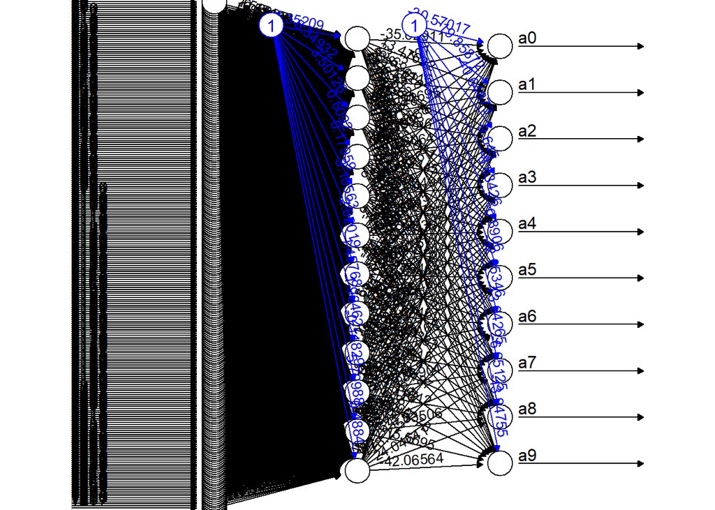

```r
plot(fitnn1, rep="best")
```

```r
#plot(fitnn2, rep="best")
#plot(fitnn3, rep="best")
#plot(fitnn4, rep="best")
```

We will assess the accuracy of the prediction using the independent testing set zip.test_s

```r
# function for creating the confusion table and accuracy rate
prediction <- function(fitnn)
{
 btest <- zip.test_s[,-1]
 prednn <- compute(fitnn, btest)
 resind <- apply(prednn$net.result, 1, which.max)
 pred <- (0:9)[resind]
 confusion <- table(pred, zip.test_s[,1])
 cat("Confusion table")
 print(confusion)
 accuracy <- sum(diag(confusion))/length(pred)
 cat("Accuracy = ", accuracy, "\n")
}
prediction(fitnn1)
```

```
## Confusion table
## pred  0  1  2  3  4  5  6  7  8  9
##    0 30  0  1  1  0  0  0  0  1  0
##    1  0 27  0  0  0  0  0  0  0  0
##    2  0  0 14  0  0  0  0  0  2  0
##    3  1  0  1 14  0  0  0  0  1  0
##    4  0  0  1  1 15  0  0  2  2  1
##    5  0  0  2  1  2 16  0  1  1  0
##    6  1  0  0  0  1  0 17  0  1  0
##    7  0  0  0  0  1  0  0  4  1  3
##    8  1  0  2  0  3  1  0  0 15  1
##    9  0  0  0  0  2  0  0  0  0  8
## Accuracy =  0.8
```

```r
prediction(fitnn2)
```

```
## Confusion table
## pred  0  1  2  3  4  5  6  7  8  9
##    0 31  0  2  1  0  0  0  0  1  0
##    1  0 27  0  0  0  0  0  0  0  0
##    2  1  0 16  0  0  0  0  0  2  0
##    3  0  0  0 12  0  4  0  0  2  1
##    4  0  0  2  1 20  0  0  1  1  2
##    5  0  0  1  2  1 12  1  0  0  0
##    6  0  0  0  1  0  0 16  0  0  0
##    7  1  0  0  0  0  0  0  5  0  1
##    8  0  0  0  0  0  1  0  0 17  0
##    9  0  0  0  0  3  0  0  1  1  9
## Accuracy =  0.825
```

```r
prediction(fitnn3)
```

```
## Confusion table
## pred  0  1  2  3  4  5  6  7  8  9
##    0 29  0  2  1  0  0  0  1  1  0
##    1  0 27  0  0  0  0  0  0  0  0
##    2  0  0 17  1  0  0  1  0  1  0
##    3  1  0  0 11  0  2  0  0  1  0
##    4  0  0  0  1 20  1  0  1  2  1
##    5  0  0  0  2  0 13  0  0  0  0
##    6  1  0  0  0  0  0 16  0  1  0
##    7  0  0  0  0  0  1  0  5  0  1
##    8  1  0  2  1  2  0  0  0 18  1
##    9  1  0  0  0  2  0  0  0  0 10
## Accuracy =  0.83
```

```r
prediction(fitnn4)
```

```
## Confusion table
## pred  0  1  2  3  4  5  6  7  8  9
##    0 31  0  2  0  0  2  0  0  1  0
##    1  0 27  0  0  0  0  0  0  0  0
##    2  0  0 16  1  1  0  0  0  2  0
##    3  2  0  0 11  0  1  0  0  0  0
##    4  0  0  1  1 22  0  0  1  0  1
##    5  0  0  0  3  0 13  0  1  1  0
##    6  0  0  2  0  0  0 17  0  0  0
##    7  0  0  0  0  0  0  0  4  1  1
##    8  0  0  0  1  1  1  0  0 19  1
##    9  0  0  0  0  0  0  0  1  0 10
## Accuracy =  0.85
```